# week05_excercise_report_Collins

Mallory Collins

2026-04-17

This is the first block that installs everything needed

```r
if (!require("tidyverse")) install.packages("tidyverse")
if (!require("gapminder")) install.packages("gapminder")
library(tidyverse)
library(gapminder)

data <- gapminder
```

Inspect data set

```r
glimpse(data)
```

```
## Rows: 1,704
## Columns: 6
## $ country   <fct> "Afghanistan", "Afghanistan", "Afghanistan", "Afghanistan", …
## $ continent <fct> Asia, Asia, Asia, Asia, Asia, Asia, Asia, Asia, Asia, Asia, …
## $ year      <int> 1952, 1957, 1962, 1967, 1972, 1977, 1982, 1987, 1992, 1997, …
## $ lifeExp   <dbl> 28.801, 30.332, 31.997, 34.020, 36.088, 38.438, 39.854, 40.8…
## $ pop       <int> 8425333, 9240934, 10267083, 11537966, 13079460, 14880372, 12…
## $ gdpPercap <dbl> 779.4453, 820.8530, 853.1007, 836.1971, 739.9811, 786.1134, …
```

```r
dim(data)
```

```
## [1] 1704    6
```

```r
names(data)
```

```
## [1] "country"   "continent" "year"      "lifeExp"   "pop"       "gdpPercap"
```

```r
summary_table <- data %>%
  group_by(continent) %>%
  summarise(
    mean_lifeExp = mean(lifeExp, na.rm = TRUE),
    sd_lifeExp   = sd(lifeExp, na.rm = TRUE),
    mean_gdp     = mean(gdpPercap, na.rm = TRUE),
    sd_gdp       = sd(gdpPercap, na.rm = TRUE)
  )

summary_table
```

```
## # A tibble: 5 × 5
##   continent mean_lifeExp sd_lifeExp mean_gdp sd_gdp
##   <fct>            <dbl>      <dbl>    <dbl>  <dbl>
## 1 Africa            48.9       9.15    2194.  2828.
## 2 Americas          64.7       9.35    7136.  6397.
## 3 Asia              60.1      11.9     7902. 14045.
## 4 Europe            71.9       5.43   14469.  9355.
## 5 Oceania           74.3       3.80   18622.  6359.
```

The above is the summary of life expectancy GDP/continent

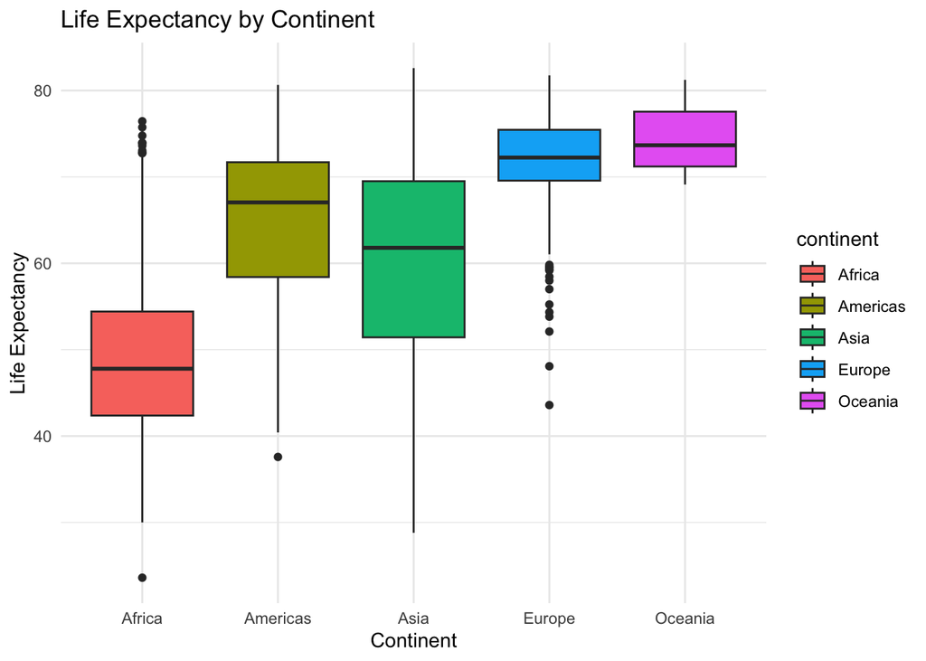

```r
lifeexp_plot <- ggplot(data, aes(x = continent, y = lifeExp, fill = continent)) +
  geom_boxplot() +
  labs(
    title = "Life Expectancy by Continent",
    x = "Continent",
    y = "Life Expectancy"
  ) +
  theme_minimal()

lifeexp_plot
```

```r
anova_model <- aov(lifeExp ~ continent, data = data)
summary(anova_model)
```

```
##               Df Sum Sq Mean Sq F value Pr(>F)
## continent      4 139343   34836   408.7 <2e-16 ***
## Residuals   1699 144805      85
## ---
## Signif. codes:  0 '***' 0.001 '**' 0.01 '*' 0.05 '.' 0.1 ' ' 1
```

```r
TukeyHSD(anova_model)
```

```
##   Tukey multiple comparisons of means
##     95% family-wise confidence level
##
## Fit: aov(formula = lifeExp ~ continent, data = data)
##
## $continent
##                       diff       lwr       upr     p adj
## Americas-Africa  15.793407 14.022263 17.564550 0.0000000
## Asia-Africa      11.199573  9.579887 12.819259 0.0000000
## Europe-Africa    23.038356 21.369862 24.706850 0.0000000
## Oceania-Africa   25.460878 20.216908 30.704848 0.0000000
## Asia-Americas    -4.593833 -6.523432 -2.664235 0.0000000
## Europe-Americas   7.244949  5.274203  9.215696 0.0000000
## Oceania-Americas  9.667472  4.319650 15.015293 0.0000086
## Europe-Asia      11.838783 10.002952 13.674614 0.0000000
## Oceania-Asia     14.261305  8.961718 19.560892 0.0000000
## Oceania-Europe    2.422522 -2.892185  7.737230 0.7250559
```

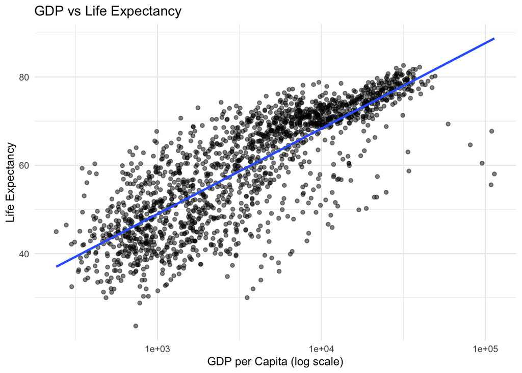

```r
gdp_plot <- ggplot(data, aes(x = gdpPercap, y = lifeExp)) +
  geom_point(alpha = 0.5) +
  scale_x_log10() +
  geom_smooth(method = "lm", se = FALSE) +
  labs(
    title = "GDP vs Life Expectancy",
    x = "GDP per Capita (log scale)",
    y = "Life Expectancy"
  ) +
  theme_minimal()

gdp_plot
```

```r
lm_model <- lm(lifeExp ~ log10(gdpPercap), data = data)
summary(lm_model)
```

```
##
## Call:
## lm(formula = lifeExp ~ log10(gdpPercap), data = data)
##
## Residuals:
##     Min      1Q  Median      3Q     Max
## -32.778  -4.204   1.212   4.658  19.285
##
## Coefficients:
##                  Estimate Std. Error t value Pr(>|t|)
## (Intercept)       -9.1009     1.2277  -7.413 1.93e-13 ***
## log10(gdpPercap)  19.3534     0.3425  56.500  < 2e-16 ***
## ---
## Signif. codes:  0 '***' 0.001 '**' 0.01 '*' 0.05 '.' 0.1 ' ' 1
##
## Residual standard error: 7.62 on 1702 degrees of freedom
## Multiple R-squared:  0.6522, Adjusted R-squared:  0.652
## F-statistic:  3192 on 1 and 1702 DF,  p-value: < 2.2e-16
```

#Discussion Countries with higher GDPs may have more money to put towards access to resources that will improve life expectancy. Since the data set uses national averages, it may not represent disparities within countries. No, the statistical significance only tells us that there is a significant between the values in the data set. However, it does not represent if the GDP actually has a large biological effect on the quality and length of life. Country population may bias the data set. Countries with larger populations will have more data.